# Machine Learning with R and Caret

Carlos Fernandez-Lozano, PhD

Last modified: 14 dic 2020

**DISCLAIMER** this course is for teaching purposes, not for a regular cancer analysis using ML. Furthermore, it offers more open questions than answers ;)

# Session info

`sessionInfo()` display which version of R you are running in which platform and operative system, the locale you are using and the attached packages.

```r
library(TCGAbiolinks)
library(SummarizedExperiment)
library(biomaRt)
library(GEOquery)
```

```r
library(ggplot2)
library(caret)
library(tibble)
library(tidyr)
library(dplyr)
library(stringr)
```

[session information not shown]

# Outline

In this course, we review some of the fundamentals of machine learning (ML) with `Caret` and R. Topics covered include:

- Exploratory data analysis
- Data pre-processing
- Machine learning models: Random Forest and Linear Discriminant Analysis
- Model comparison

And the question now is the following: What is Machine Learning? Firstly, a hot topic in the last years. Generally speaking, a system that can access data and use it to learn and extract underlying knowledge from it in order to automatically learn without being explicitly programmed for it. So, it learns from your data (handle with care), it’s fast and it tends to overfits to your data (handle with care). So we are able to build a model on the data and then use it to predict on new data. They learn patterns from the data so a particular pattern not present in your data could not been predicted nor even known by the model. Furthermore, the big assumption here is that “what we learn from the past will be used to predict the future” and as we know, the future in unpredictable. So **handle with care** following a good experimental design to reduce the uncertainties.

A ML is said to overfit if the algoritms is more accurate predicting/fitting to known data (used in the training of the algorithm) than in predicting with new unknown data. A good generalization capability is thus desired. We will cover some tasks for a proper experimental design in classification problems despite the fact that there are other problems in ML research such as: regression, survival, clustering and much more. A methodology for the design of experiments with regression models is available open access [here](https://peerj.com/articles/2721/).

# Caret

Nowadays one of the strenghts in ML research is that you can search for a particular algorithm in a particular programming language and you’ll have several different implemenations. Even more, if you need to build a ML model you’ll have several differnt robust methodologies. At the same time, the big drawback is that everything is here and YOU must handle it with care. Otherways you’ll build a bad model with a poor prediction and generalization capability. This means **problems**!

One of the biggest efforts to normalize, democratize and standardize ML using R is the `Caret` package, a bookdown [here](https://topepo.github.io/caret/). Developed by Max Kuhn, is a single interface to hundred or thousands of functions through a complex ML pipeline. The `caret` package (short for **C**lassification **A**nd **R**egression **T**raining) contains tools for:

- data splitting
- pre-processing
- feature selection
- model tuning
- variable importance
- and much more functionalities…

Following the `caret` documentation [suggestion](https://cran.r-project.org/web/packages/caret/vignettes/caret.html), in order to install the package execute the following package to ensure that all needed packages are installed and resolve all the dependencies:

```r
install.packages("caret", dependencies = c("Depends", "Suggests"))
```

Be patient, it may take a while!

[session information not shown]

# TCGA - BRCA dataset

```r
query = GDCquery(project = 'TCGA-BRCA',
         data.category = 'Transcriptome Profiling',
         data.type = 'Gene Expression Quantification',
         experimental.strategy = 'RNA-Seq',
         workflow.type = 'HTSeq - FPKM-UQ')

GDCdownload(query)

brca.expDat = GDCprepare(query = query,
                    save = T,
                    save.filename = "TCGA-BRCA-RNASeq",
                    remove.files.prepared =  TRUE)

brca.omics = assay(brca.expDat)
brca.omics = as.data.frame(t(brca.omics))

samples = colData(brca.expDat)
rownames(samples) = 1:nrow(samples)
ptSamples = samples[which(samples$definition == 'Primary solid Tumor'), ]

ptSamples = ptSamples[, c('barcode', 'patient', 'vital_status', 'days_to_last_follow_up', 'days_to_death', 'gender', 'age_at_diagnosis','ajcc_pathologic_stage',
                          'tumor_stage','ajcc_pathologic_n','tumor_grade')]

mart <- useDataset("hsapiens_gene_ensembl", useMart("ensembl"))
convert <- getBM(filters= c('ensembl_gene_id'),
                 attributes= c('ensembl_gene_id', 'gene_biotype'),
                 values=names(brca.omics),
                 mart= mart)
protCod = convert[which(convert$gene_biotype == 'protein_coding'), ]
protCodIDs = protCod$ensembl_gene_id
brca.omics = brca.omics[, match(protCodIDs, names(brca.omics))]

platID96 = 'GPL96'

gpl96 = getGEO(platID96)

gpl96 = gpl96@dataTable@table
annot96 = gpl96[, c('ID', 'Gene Symbol', 'Gene Title', 'ENTREZ_GENE_ID')]

dict96 = getBM(filters= c('affy_hg_u133a'),
               attributes= c('ensembl_gene_id', 'affy_hg_u133a','hgnc_symbol'),
               values= annot96$ID,
               mart= mart)

genes96 = unique(dict96$ensembl_gene_id)
brca.omics.96 = brca.omics[, intersect(names(brca.omics), genes96)]

colnames(brca.omics.96)<- dict96$hgnc_symbol[match(colnames(brca.omics.96),dict96$ensembl_gene_id)]
```

**NOTE:** Files `brca.omics.96` and `ptSamples` are available for download from the Universidade da Coruña’s community in Zenodo [here](https://doi.org/10.5281/zenodo.4309168). Load them in R using the `readRDS()` function.

```r
brca.omics.96<-readRDS(file = '~/Downloads/TCGA.BRCA.brca.omics.96.RData')
ptSamples <- readRDS(file = '~/Downloads/TCGA.BRCA.ptSamples.RData')
```

## Exploratory data analysis

Before training any ML model it’s important to understand your data. Thus, an initial descriptive exploratory analysis is of interest. For exaple, some typical errors arise during the loading process of the data. Furthermore, sometimes codification problems such as slash, values of 0 for unknown data or other similar situations.

## Features types.

One of the initial steps should be the check of the types of the features in order to check that all numeric values are numbers for R and that cualitative features are factor or boolean for example. You can do this task with `str()` from base or `glimpse` from `Tibble` for example:

```r
str(brca.omics.96)
```

```
## 'data.frame':    1222 obs. of  12951 variables:
##  $ TSPAN6         : num  86245 189616 487165 332552 183541 ...
##  $ TNMD           : num  9823 485 4387 1392 66632 ...
##  $ DPM1           : num  668495 659655 1015760 561152 490427 ...
##  $ SCYL3          : num  83027 55156 87009 76102 149817 ...
##  $ C1orf112       : num  35118 36692 66101 28917 54872 ...
##  $ FGR            : num  21011 76122 31996 20319 21727 ...
##  $ CFH            : num  123409 122942 53081 106680 180188 ...
##  $ GCLC           : num  179937 94910 83284 103929 91870 ...
##  $ NFYA           : num  411314 396216 470659 389408 210799 ...
##  $ NIPAL3         : num  113323 340823 39135 243773 112292 ...
##  $ LAS1L          : num  167550 209827 402011 216011 241211 ...
##  $ ENPP4          : num  34265 94652 74573 42640 134035 ...
##  $ SEMA3F         : num  486517 100325 307889 477688 886045 ...
##  $ CFTR           : num  892.7 61.1 7900.2 723.5 287.2 ...
```

[output cut: 86 more lines]

```r
glimpse(brca.omics.96)
```

We lost some information in the previous matching process using `BioMart` and we also observed that some of the genes have 0’s.

```r
str(ptSamples)
```

```
## Formal class 'DFrame' [package "S4Vectors"] with 6 slots
##   ..@ rownames       : chr [1:1102] "1" "2" "3" "4" ...
##   ..@ nrows          : int 1102
##   ..@ listData       :List of 11
##   .. ..$ barcode               : chr [1:1102] "TCGA-A2-A1FW-01A-11R-A13Q-07" "TCGA-AO-A0J4-01A-11R-A034-07" "TCGA-AN-A04C-01A-21R-A034-07" "TCGA-EW-A1P6-01A-11R-A144-07" ...
##   .. ..$ patient               : chr [1:1102] "TCGA-A2-A1FW" "TCGA-AO-A0J4" "TCGA-AN-A04C" "TCGA-EW-A1P6" ...
##   .. ..$ vital_status          : chr [1:1102] "Alive" "Alive" "Alive" "Alive" ...
##   .. ..$ days_to_last_follow_up: int [1:1102] 528 1587 54 562 890 NA 30 1066 NA 1371 ...
##   .. ..$ days_to_death         : int [1:1102] NA NA NA NA NA 2573 NA NA 1642 NA ...
##   .. ..$ gender                : chr [1:1102] "female" "female" "female" "female" ...
##   .. ..$ age_at_diagnosis      : int [1:1102] 22779 15052 18851 23485 23284 16705 19298 21464 26684 30711 ...
##   .. ..$ ajcc_pathologic_stage : chr [1:1102] "Stage IIIA" "Stage IA" "Stage IIB" "Stage IIB" ...
##   .. ..$ tumor_stage           : chr [1:1102] "stage iiia" "stage ia" "stage iib" "stage iib" ...
##   .. ..$ ajcc_pathologic_n     : chr [1:1102] "N2a" "N0 (i-)" "N1" "N1a" ...
##   .. ..$ tumor_grade           : chr [1:1102] "not reported" "not reported" "not reported" "not reported" ...
##   ..@ elementType    : chr "ANY"
##   ..@ elementMetadata: NULL
##   ..@ metadata       : list()
```

```r
ptSamples<-as.data.frame(ptSamples)
```

We have all the cuantitative features as `character` so we should fix this. In this case, we will add new features with an extension in order to have a copy of the original feature for reproducibility and error checking pouposes.

```r
ptSamples$gender.fac <- as.factor(ptSamples$gender)
ptSamples$vital_status.fac <- as.factor(ptSamples$vital_status)
```

In case of further changes we’ll fix features in the following part of the course.

We have to remove firstly those features without a gene name (empty colnames) because `dplyr` cannot deal with repeated colnames.

```r
brca.omics.96 <-subset(brca.omics.96, select=which(!duplicated(names(brca.omics.96))))
keep.cols <- names(brca.omics.96) %in% c("")
brca.omics.96 <- brca.omics.96 [!keep.cols]
```

We should check for NA’s in both files:

```r
length(which(is.na(ptSamples)))
```

```
## [1] 1089
```

```r
length(which(is.na(brca.omics.96)))
```

```
## [1] 0
```

No NAs on omic data but in clinical.

We’ll follow the `Tidiverse` philosophy in order to create a new data structure to facilitate further data visualizations.

```r
ptSamples.tidy <- ptSamples %>% gather(key = "feature", value = "value", -barcode)
```

Let’s ggplot the % of NAs in each of the clinical features.

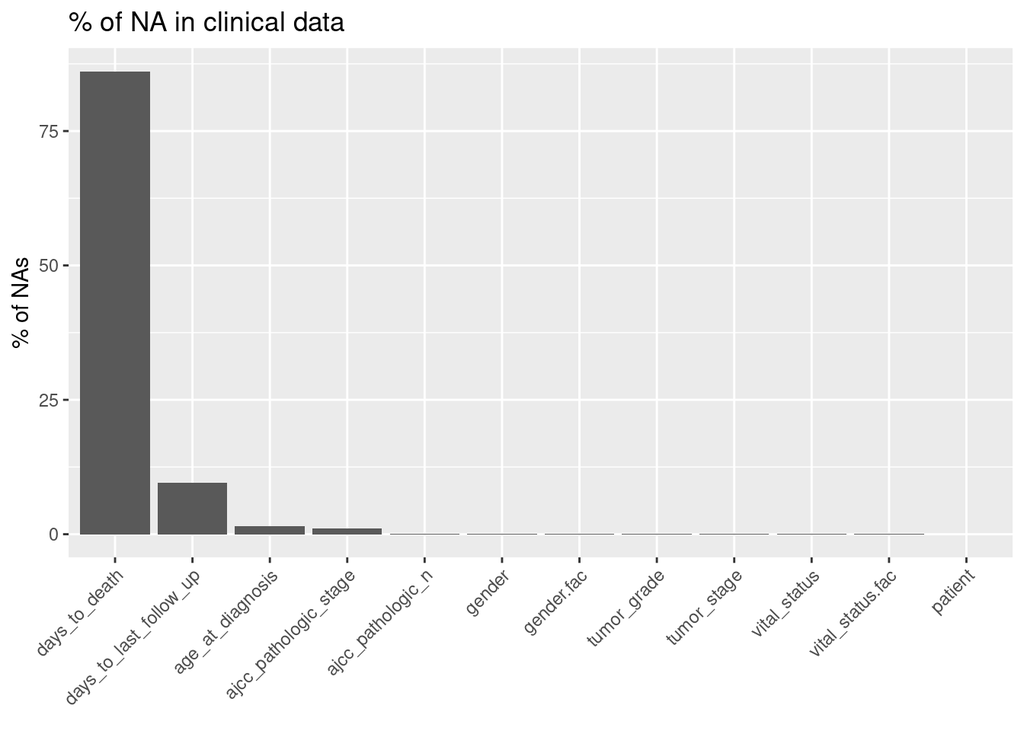

```r
ptSamples.tidy %>%
  group_by(feature) %>%
  summarize(NAs = 100 * sum(is.na(value)) / length(value)) %>%
  ggplot(aes(x = reorder(feature, dplyr::desc(NAs)), y = NAs)) +
    geom_col() +
    labs(title = "% of NA in clinical data", x=element_blank(), y = "% of NAs") +
    theme(axis.text.x = element_text(angle = 45,hjust = 1))
```

Summarising, we don’t have enough data in `days_to_death` with a % of NAs higher than 86% and have some missing data in other features but seems to be afordable.

Let’s check the distribution of `gender` and `vital_status`:

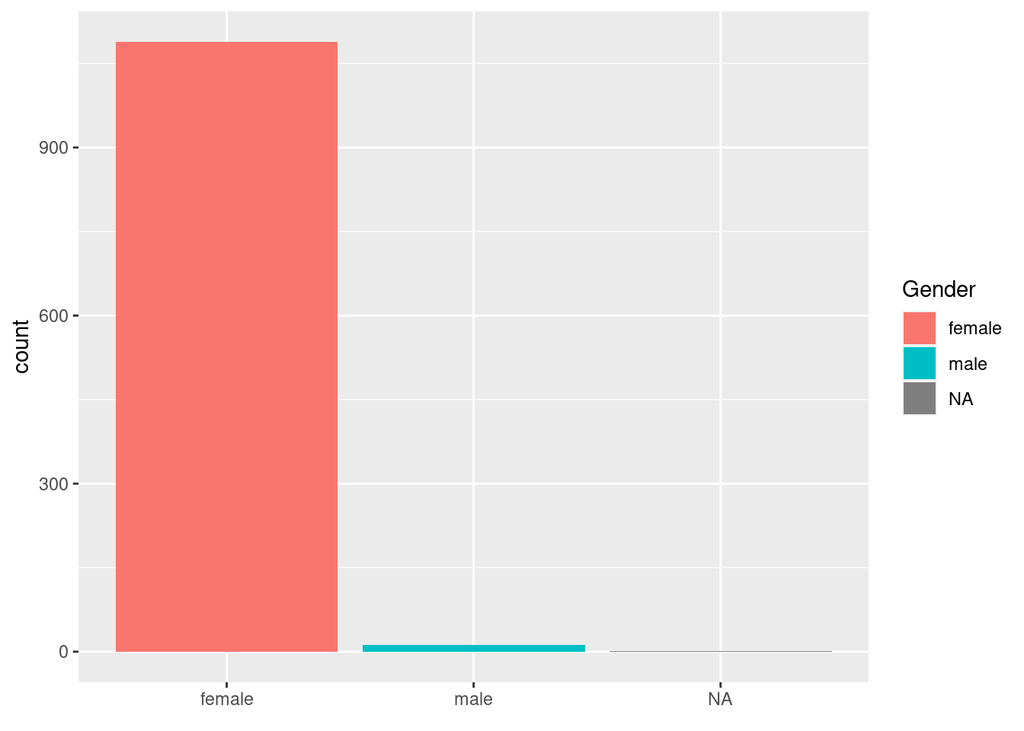

```r
ggplot(data = ptSamples, aes(x = gender.fac, y = ..count.., fill = gender.fac)) +
  geom_bar() +
  labs(fill='Gender',
       x=element_blank())
```

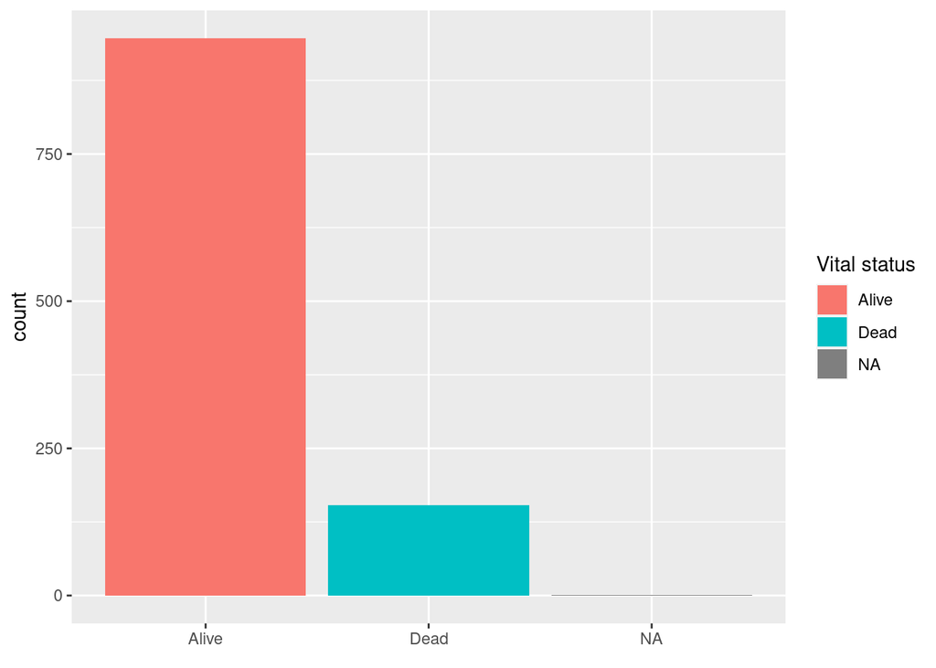

```r
ggplot(data = ptSamples, aes(x = vital_status.fac, y = ..count.., fill = vital_status.fac)) +
  geom_bar() +
  labs(fill='Vital status',
       x=element_blank())
```

In both cases, patient with barcode `TCGA-BH-A0B2-01A-11R-A10J-07` has all clinical values to NAs. We remove this patient.

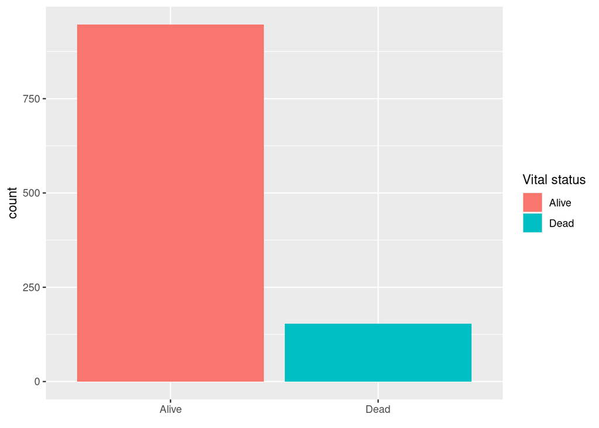

```r
ptSamples<-ptSamples %>% filter(barcode!='TCGA-BH-A0B2-01A-11R-A10J-07')

ggplot(data = ptSamples, aes(x = vital_status.fac, y = ..count.., fill = vital_status.fac)) +
  geom_bar() +
  labs(fill='Vital status',
       x=element_blank())
```

Let’s play with `ajcc_pathologic_stage` and remove blank spaces in the different stages with `stringr`:

```r
ptSamples$ajcc_pathologic_stage<-str_replace_all(ptSamples$ajcc_pathologic_stage, ' ','')
ptSamples$ajcc_pathologic_stage.fac <- as.factor(ptSamples$ajcc_pathologic_stage)
```

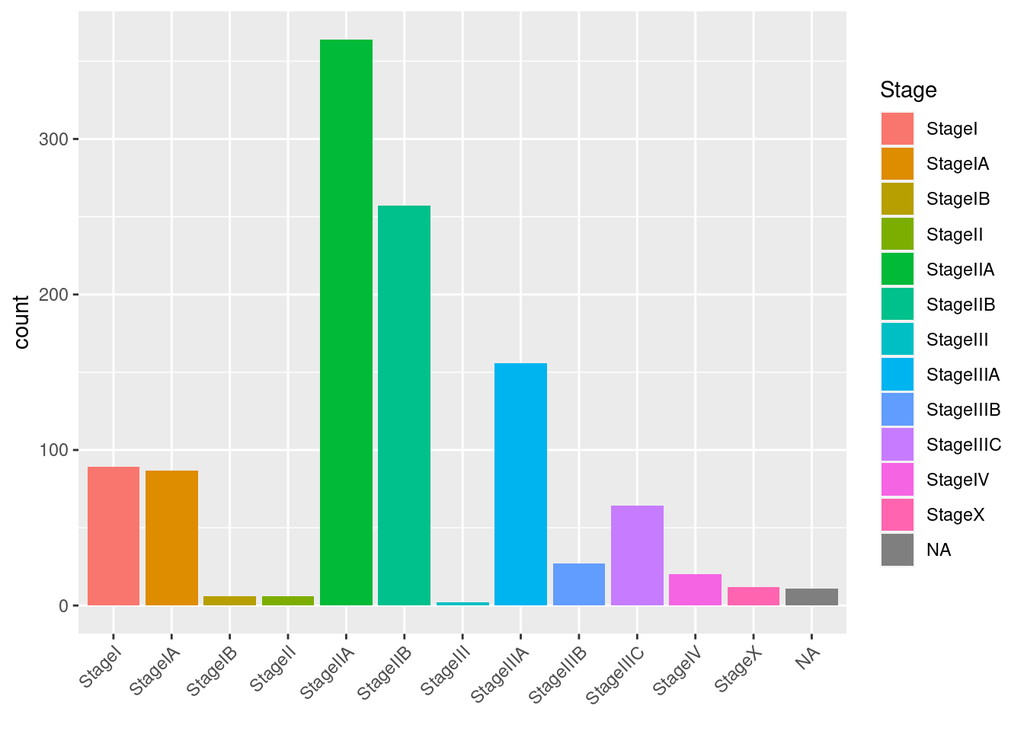

```r
ggplot(data = ptSamples, aes(x = ajcc_pathologic_stage.fac, y = ..count.., fill = ajcc_pathologic_stage.fac)) +
  geom_bar() +
  labs(fill='Stage',
       x=element_blank())+
  theme(axis.text.x = element_text(angle = 45,hjust = 1))
```

[figure not shown]

```r
ptSamples<-mutate(ptSamples, ajcc_pathologic_stage_new_3 =
         ifelse(ajcc_pathologic_stage %in% c('StageI','StageIA','StageIB'),'Stage1',
                ifelse(ajcc_pathologic_stage %in% c('StageII','StageIIA','StageIIB'),'Stage2',
                       ifelse(ajcc_pathologic_stage %in% c('StageIII','StageIIIA','StageIIIB','StageIIIC'),'Stage3',
                              ifelse(ajcc_pathologic_stage %in% c('StageIV','StageX'),'Stage4','Others')
                                )
                       )
                )
       )

ggplot(data = ptSamples, aes(x = ajcc_pathologic_stage_new_3, y = ..count.., fill = ajcc_pathologic_stage_new_3)) +
  geom_bar() +
  labs(fill='New stage with 3 levels',
       x=element_blank(),
       y=element_blank())+
  theme(axis.text.x = element_text(angle = 45,hjust = 1))
```

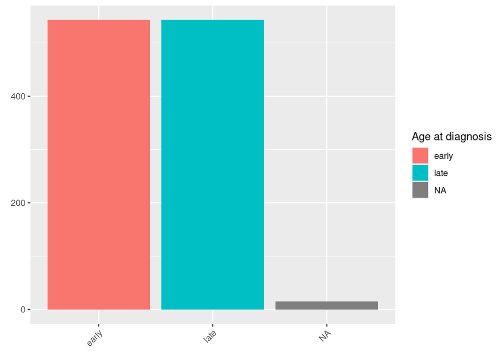

```r
ptSamples<-mutate(ptSamples, age_at_diagnosis.fac =
         ifelse(age_at_diagnosis<21560,'early','late')
       )

ggplot(data = ptSamples, aes(x = age_at_diagnosis.fac, y = ..count.., fill = age_at_diagnosis.fac)) +
  geom_bar() +
  labs(fill='Age at diagnosis',
       x=element_blank(),
       y=element_blank())+
  theme(axis.text.x = element_text(angle = 45,hjust = 1))
```

We will study if there exist a genomic pattern for classifying BRCA patients according with this new binary age at diagnosis.

```r
ptSamples<-ptSamples %>% drop_na(age_at_diagnosis.fac)
```

## Train and test dataset

In order to evaluate the predictive power of the ML we must ensure that the model’s performance should be equal (or close to) with unknown new patients. In orther to do this, we’ll separate the dataset in two groups: training and test (80-20%) according with the output. Furthermore, this dataset has a FPKM normalization (reads/fragments per kilobase of exon per million reads/fragments mapped) but most of the ML models are sensible to differences in the scale of the features so, there are mainly two different approaches: normalization or standardization. Generally speaking, standardization (scale the features to have a mean of 0 and a standard deviation of 1) is preferred. In R we have the `scale()` function. This step belongs to the next section (data preprocessing) but it’s preferable to do it before data splitting.

```r
brca.data <- as.data.frame(scale(brca.omics.96))
mean(brca.data$TP53)
```

```
## [1] 4.720831e-17
```

```r
sd(brca.data$TP53)
```

```
## [1] 1
```

```r
brca.data$output <- ptSamples[match(row.names(brca.data),ptSamples$barcode),"age_at_diagnosis.fac"]
brca.data <- brca.data %>% drop_na(output)
```

Ok but, what does this standardization looks like? in order to use `ggplot2` to boxplot three aleatory genes we need data in [long format](https://statisticsglobe.com/reshape-data-frame-from-wide-to-long-format-in-r) and fortunatelly we have the `reshape` package and the `melt()` function to help us.

```r
library(reshape2)
data.raw <- melt(brca.omics.96[,c(1,2,3)])
data.scale <- melt(brca.data[,c(1,2,3)])
```

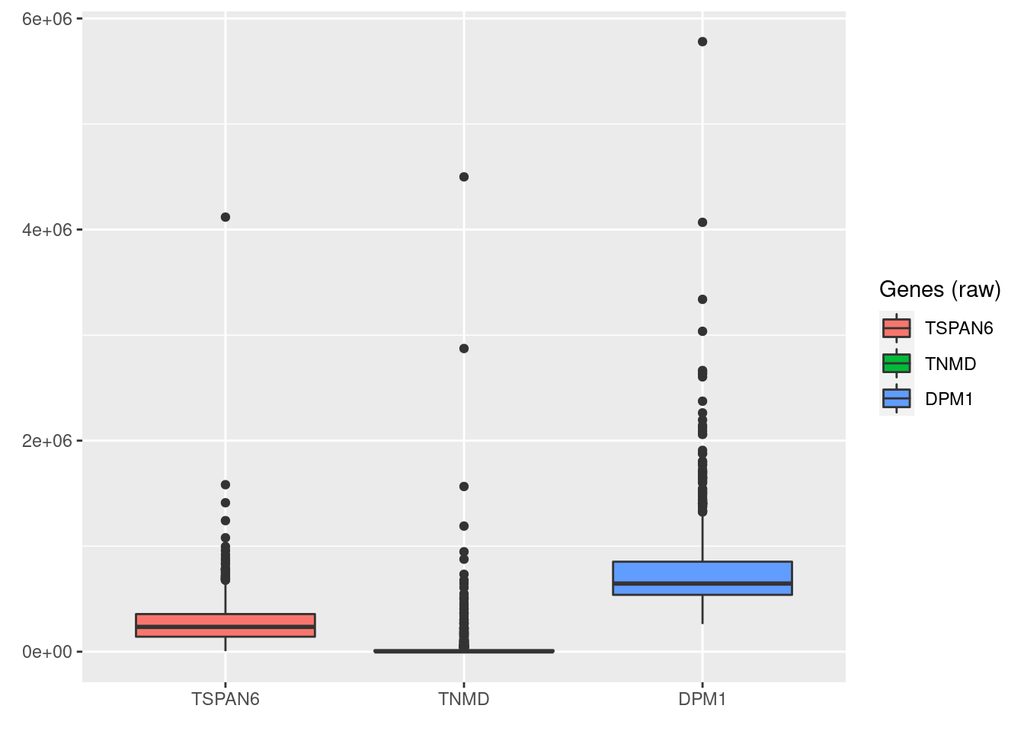

```r
ggplot(data.raw, aes(x = variable, y = value, fill=variable)) +
  geom_boxplot()+
  labs(x=element_blank(),
       y=element_blank(),
       fill='Genes (raw)')
```

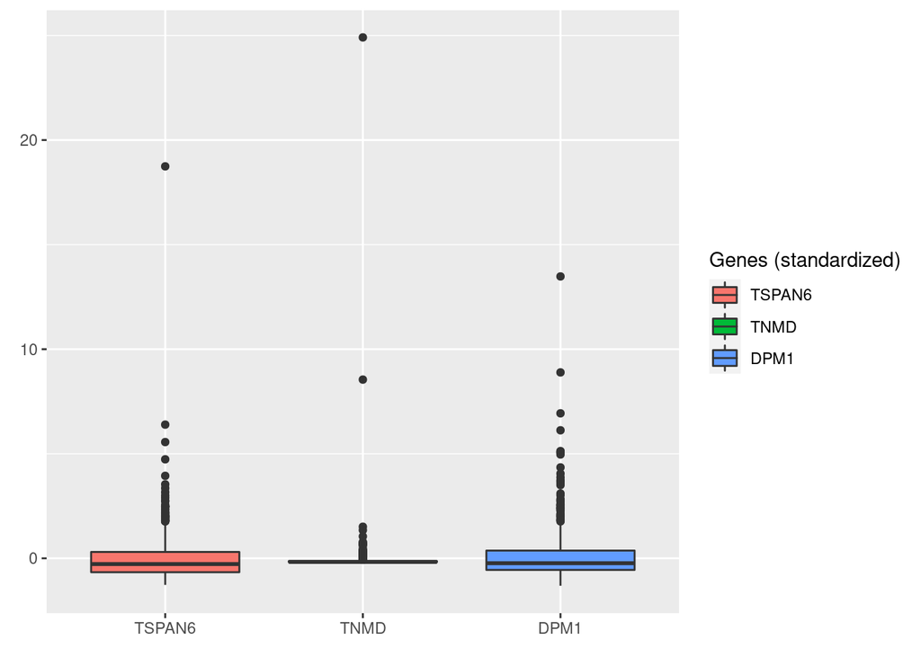

```r
ggplot(data.scale, aes(x = variable, y = value, fill=variable)) +
  geom_boxplot()+
  labs(x=element_blank(),
       y=element_blank(),
       fill='Genes (standardized)')
```

Looks pretty similar, or not? Let’s check what’s going on:

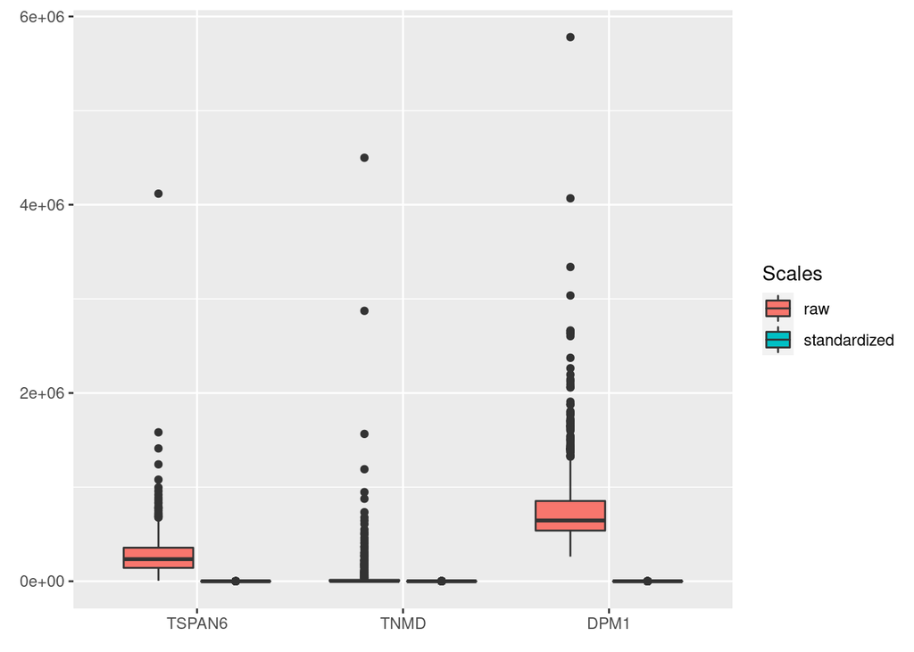

```r
data.raw$type <- 'raw'
data.scale$type <- 'standardized'
data.comparison <- rbind(data.raw,data.scale)
ggplot(data.comparison, aes(x = variable, y = value, fill=type)) +
  geom_boxplot()+
  labs(x=element_blank(),
       y=element_blank(),
       fill='Scales')
```

A good idea is to stratify the groups to have equal proportion of each one of the classes (in binary classification).

```r
set.seed(23)

train <- createDataPartition(y = brca.data$output, p = 0.8, list = FALSE, times = 1)
brca.data_train <- brca.data[train, ]
brca.data_test  <- brca.data[-train, ]
```

## Data preprocessing

`Caret` has several different useful functions for all the steps of a ML analysis pipeline. One of them is `nearZeroVar()` to remove those features with a single value (zero-variance) because they are useless.

```r
nzv <- nearZeroVar(brca.data)
head(nzv)
```

```
## [1]  538 1324 1721 1833 1915 1944
```

```r
length(nzv)
```

```
## [1] 251
```

```r
brca.data.nzv <- brca.data[,-nzv]
```

By default, `nearZeroVar` will return the positions of the problematic features. We remove those features.

Most of the models may benefit from reducing the level of correlation between features. More correlation does not imply more information and, on the other hand, likely imply more noise. `Caret` has a `findCorrelation()` function for this task.

```r
output <- brca.data.nzv %>% select('output')
data <- brca.data.nzv[,setdiff(colnames(brca.data.nzv),'output')]
high.cor <- findCorrelation(data, cutoff = .75)
brca.data.nzv.cor <- brca.data.nzv[,-high.cor]
brca.data.nzv.cor$output <- output
```

A cutoff of `.75` is clearly too much ;)

We will keep the final set of genes as the ones of interest so we must keep them too in the train and test datasets:

```r
brca.data_train <- brca.data_train %>% select(names(brca.data.nzv.cor))
brca.data_test <- brca.data_test %>% select(names(brca.data.nzv.cor))
```

## Machine Learning models: Random Forest and Linear Discriminant Analysis

In the following sections we will train and tune two ML models: Random Forest and Linear Discriminant Analysis and we’ll compare them with the same train and test datasets.

### Random Forest

Random forest [(RF)](https://link.springer.com/article/10.1023/A:1010933404324) combines several classification trees, which are fitted to subsamples of the original sample-set using randomly selected subsets of predictor variables. From the complete *forest*, a single global prediction is obtained as an average (in case of regression) or majority vote (in case of classification) of the prediction of all trees. The advantages of this method are: (1) it is simple and results are easy to interpret in the case of few predictors; and (2) it can be applied to many problems, even if there are high-order interaction effects or non-linear relationships between the variables. The `ranger` R package was used for the analysis. We’ll need more dependencies: `e1071`… **REMEMBER**: use `Caret` to rule them all!

In order to follow a robust experimental design we’ll follow [this](https://peerj.com/articles/2721/) approach with 5 runs of a 10-fold cross-validation approach. This particular implementation of the RF has the following hyperparameters:

- *mtry*: number of features randomly selected for each tree. We’ll test with the following range: 3, 5, 7.
- *min.node.size*: minimum node’s size to be divided. We’ll test with the following range: 2, 4, 6.
- *splitrule*: division criteria.

Furthermore, hyperparameter tuning could be expensive in terms of computational power. In order to increase the speed of working we’ll use a package for paralelization (without coding especifically nothing!) called `doParallel`. Remember to `install.packages('doParallel')`.

```r
library(doParallel)
cl <- makePSOCKcluster(3)
registerDoParallel(cl)

cv.k  <- 10
reps <- 5

hyperparameters <- expand.grid(mtry = c(3, 5, 7),
                               min.node.size = c(2, 4, 6),
                               splitrule = "gini")

set.seed(1234)
seeds <- vector(mode = "list", length = (cv.k * reps) + 1)
for (i in 1:(cv.k * reps)) {
  seeds[[i]] <- sample.int(1000, nrow(hyperparameters))
}
seeds[[(cv.k * reps) + 1]] <- sample.int(1000, 1)

train.control <- trainControl(method = "repeatedcv", number = cv.k,
                              repeats = reps, seeds = seeds,
                              returnResamp = "final", verboseIter = TRUE,
                              allowParallel = TRUE)

set.seed(5678)
rf.model <- train(x = brca.data_train[,-ncol(brca.data_train)],
                  y= brca.data_train$output,
                  method = "ranger",
                  tuneGrid = hyperparameters,
                  metric = "Accuracy",
                  importance= 'impurity',
                  trControl = train.control,
                  num.trees = 500)
rf.model
```

```
## Random Forest
##
## 870 samples
## 625 predictors
##   2 classes: 'early', 'late'
##
## No pre-processing
## Resampling: Cross-Validated (10 fold, repeated 5 times)
## Summary of sample sizes: 784, 782, 782, 784, 783, 782, ...
## Resampling results across tuning parameters:
##
##   mtry  min.node.size  Accuracy   Kappa
##   3     2              0.6284547  0.2569463
##   3     4              0.6339461  0.2679904
##   3     6              0.6222001  0.2444328
##   5     2              0.6350775  0.2702316
##   5     4              0.6357696  0.2715789
##   5     6              0.6403599  0.2807841
##   7     2              0.6417760  0.2836317
##   7     4              0.6396963  0.2794316
##   7     6              0.6365170  0.2731391
##
## Tuning parameter 'splitrule' was held constant at a value of gini
## Accuracy was used to select the optimal model using the largest value.
## The final values used for the model were mtry = 7, splitrule = gini
##  and min.node.size = 2.
```

**ADVANCED TIP**: In almost all cases, using a formula with `train()` will convert factors to dummy variables, however some models does not: `ranger`, `randomForest` and some others. More [info](https://www.slideshare.net/Work-Bench/i-dont-want-to-be-a-dummy-encoding-predictors-for-trees).

The final model is here:

```r
rf.model$finalModel
```

```
## Ranger result
##
## Call:
##  ranger::ranger(dependent.variable.name = ".outcome", data = x,      mtry = min(param$mtry, ncol(x)), min.node.size = param$min.node.size,      splitrule = as.character(param$splitrule), write.forest = TRUE,      probability = classProbs, ...)
##
## Type:                             Classification
## Number of trees:                  500
## Sample size:                      870
## Number of independent variables:  625
## Mtry:                             7
## Target node size:                 2
## Variable importance mode:         impurity
## Splitrule:                        gini
## OOB prediction error:             36.09 %
```

Graphically our training process was like this:

[figure not shown]

```r
ggplot(rf.model, highlight = TRUE) +
  scale_x_continuous(breaks = 1:30) +
  labs(title = "RF",subtitle = "Accuracy") +
  guides(color = guide_legend(title = "mtry"),
         shape = guide_legend(title = "mtry")) +
  theme_bw()
```

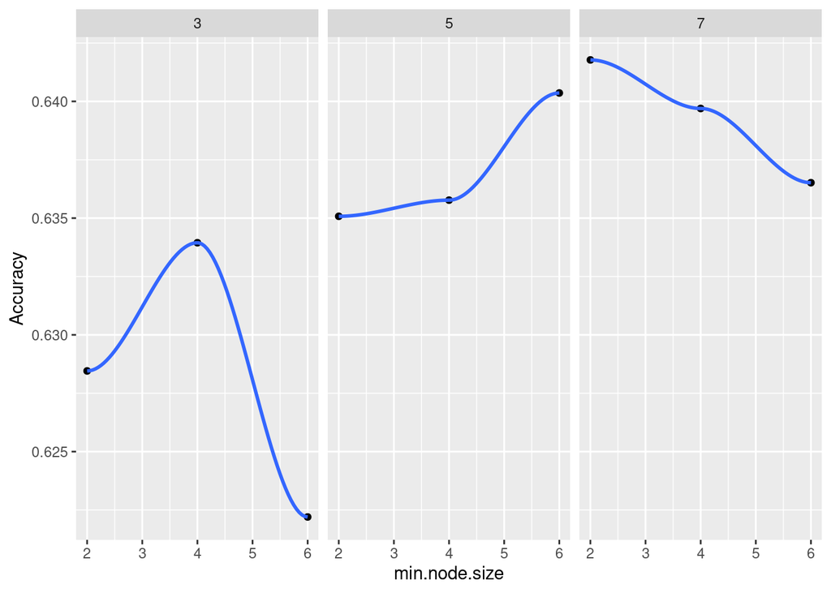

```r
rf.model$results %>%
  ggplot()+
  geom_point(aes(x = min.node.size, y = Accuracy))+
  geom_smooth(aes(x = min.node.size, y = Accuracy))+
  facet_wrap(~mtry)
```

### Linear Discriminant Analysis

One of the most used baseline ML models is Linear Discriminant Analaysi (LDA). Remember the Occam’s razor, the simplest explanation is usually the right one: less features, less hyperparameters, less complexity and so on. There is not an absolutely better ML model for every single possible task so… we should always run several different experiments with several models in order to understand and explore our problem from different points of view.

In order to follow a robust experimental design we’ll follow again [this](https://peerj.com/articles/2721/) approach with 5 runs of a 10-fold cross-validation approach.

This particular implementation of the LDA has no hyperparameters so it fits perfectly the baseline model definition.

```r
set.seed(5678)
lda.model <- train(output ~ ., data = brca.data_train,
                   method = "lda",
                   metric = "Accuracy",
                   trControl = train.control)
lda.model
```

```
## Linear Discriminant Analysis
##
## 870 samples
## 625 predictors
##   2 classes: 'early', 'late'
##
## No pre-processing
## Resampling: Cross-Validated (10 fold, repeated 5 times)
## Summary of sample sizes: 784, 782, 782, 784, 783, 782, ...
## Resampling results:
##
##   Accuracy   Kappa
##   0.5517346  0.1036177
```

The final model is here:

```r
lda.model$finalModel
```

[output not shown]

In this case, we are going to compare a complex model with three hyperparameters such as RF against a simple baseline model without hyperparameters such as LDA.

### Model comparison

After the experiments we have two ML models, trained in the same conditions and with the same experimental design so now, the question is, which is the best one?

We ran 5 repetitions of a 10-fold cross-validation experiment using `set.seed()` to ensure that both models worked on the same set of data and partitions and in the same order. With `resamples()` we can extract performance metrics for each repetition.

```r
results <- list(RF=rf.model, LDA=lda.model)
resam.results <- resamples(results)
resam.results$values %>% head()
```

|  | Resample | RF~Accuracy | RF~Kappa | LDA~Accuracy | LDA~Kappa |
| --- | --- | --- | --- | --- | --- |
| 1 | Fold01.Rep1 | 0.6162791 | 0.2325581 | 0.5581395 | 0.11627907 |
| 2 | Fold01.Rep2 | 0.6206897 | 0.2410785 | 0.5402299 | 0.08033827 |
| 3 | Fold01.Rep3 | 0.6022727 | 0.2045455 | 0.4545455 | -0.09090909 |
| 4 | Fold01.Rep4 | 0.6860465 | 0.3720930 | 0.5465116 | 0.09302326 |
| 5 | Fold01.Rep5 | 0.6321839 | 0.2650475 | 0.4827586 | -0.03434610 |
| 6 | Fold02.Rep1 | 0.6704545 | 0.3409091 | 0.5000000 | 0.00000000 |

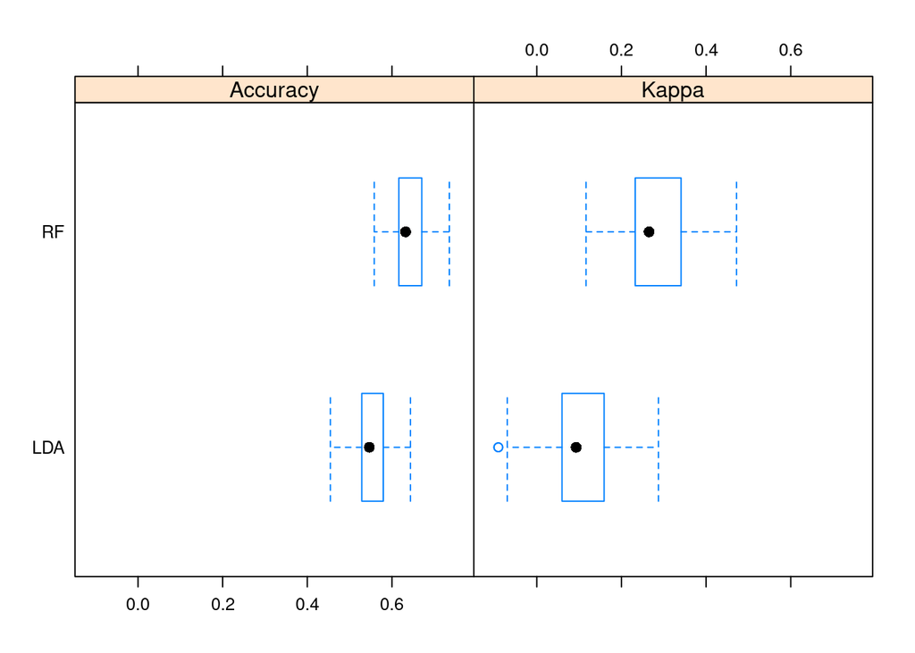

```r
bwplot(resam.results)
```

Let’s check if we have one of the models that provide better performance in terms of accuracy:

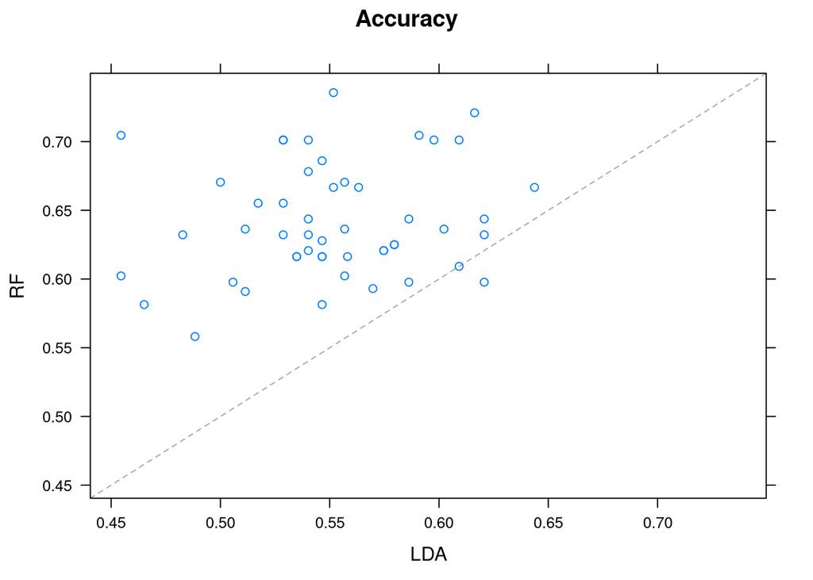

```r
xyplot(resam.results, metric = "Accuracy")
```

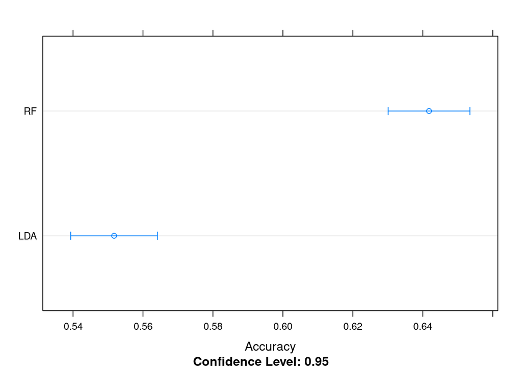

```r
dotplot(resam.results, metric = "Accuracy")
```

And finally a density plot to look for outlier folds with unusual high or low values of accuracy:

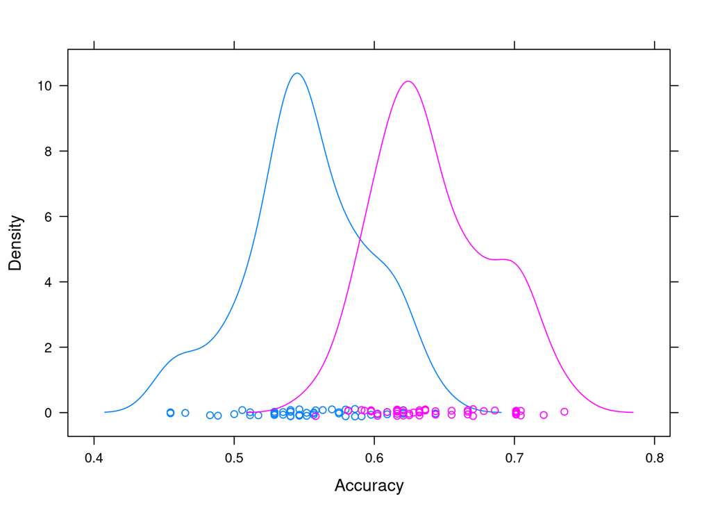

```r
densityplot(resam.results, metric = "Accuracy")
```

At this point, a good idea is to plot the results using `ggplot` and for this, we should change the data.frame to something more friedly as we did before:

```r
resam.results.gg <- resam.results$values %>%
                         gather(key = "model", value = "value", -Resample) %>%
                         separate(col = "model", into = c("model", "score"),
                                  sep = "~", remove = TRUE)
resam.results.gg %>% head()
```

|  | Resample | model | score | value |
| --- | --- | --- | --- | --- |
| 1 | Fold01.Rep1 | RF | Accuracy | 0.6162791 |
| 2 | Fold01.Rep2 | RF | Accuracy | 0.6206897 |
| 3 | Fold01.Rep3 | RF | Accuracy | 0.6022727 |
| 4 | Fold01.Rep4 | RF | Accuracy | 0.6860465 |
| 5 | Fold01.Rep5 | RF | Accuracy | 0.6321839 |
| 6 | Fold02.Rep1 | RF | Accuracy | 0.6704545 |

Let’s check the behaviour of the models during the five runs:

```r
resam.results.gg %>%
  group_by(model, score) %>%
  summarise(mean.5run = mean(value)) %>%
  spread(key = score, value = mean.5run) %>%
  arrange(desc(Accuracy))
```

| model | Accuracy | Kappa |
| --- | --- | --- |
| RF | 0.6417760 | 0.2836317 |
| LDA | 0.5517346 | 0.1036177 |

This is the training error of 5 runs of a 10-fold CV, which is a good estimator, however we have a subset of unknown patients for the models and we want to check the real generalization capability of the models. We’ll use the `extractPrediction()` function that, according to the [Rdocumentation](https://www.rdocumentation.org/packages/caret/versions/6.0-86/topics/extractPrediction) will calculate the training and test data predictions. The original training data are used to predict on.

```r
preds.results <- extractPrediction(
                  models = results,
                  testX = brca.data_test %>% select(-output),
                  testY = brca.data_test$output
                )
preds.results %>% head()
```

|  | obs | pred | model | dataType | object |
| --- | --- | --- | --- | --- | --- |
| 1 | early | early | ranger | Training | RF |
| 2 | early | early | ranger | Training | RF |
| 3 | late | late | ranger | Training | RF |
| 4 | late | late | ranger | Training | RF |
| 5 | early | early | ranger | Training | RF |
| 6 | early | early | ranger | Training | RF |

```r
preds.scores <- preds.results %>%
                         mutate(success = ifelse(obs == pred, TRUE, FALSE)) %>%
                         group_by(object, dataType) %>%
                         summarise(accuracy = mean(success))
preds.scores %>%
  spread(key = dataType, value = accuracy) %>%
  arrange(desc(Test))
```

| object | Test | Training |
| --- | --- | --- |
| RF | 0.6203704 | 1.0000000 |
| LDA | 0.5231481 | 0.9448276 |

And graphically:

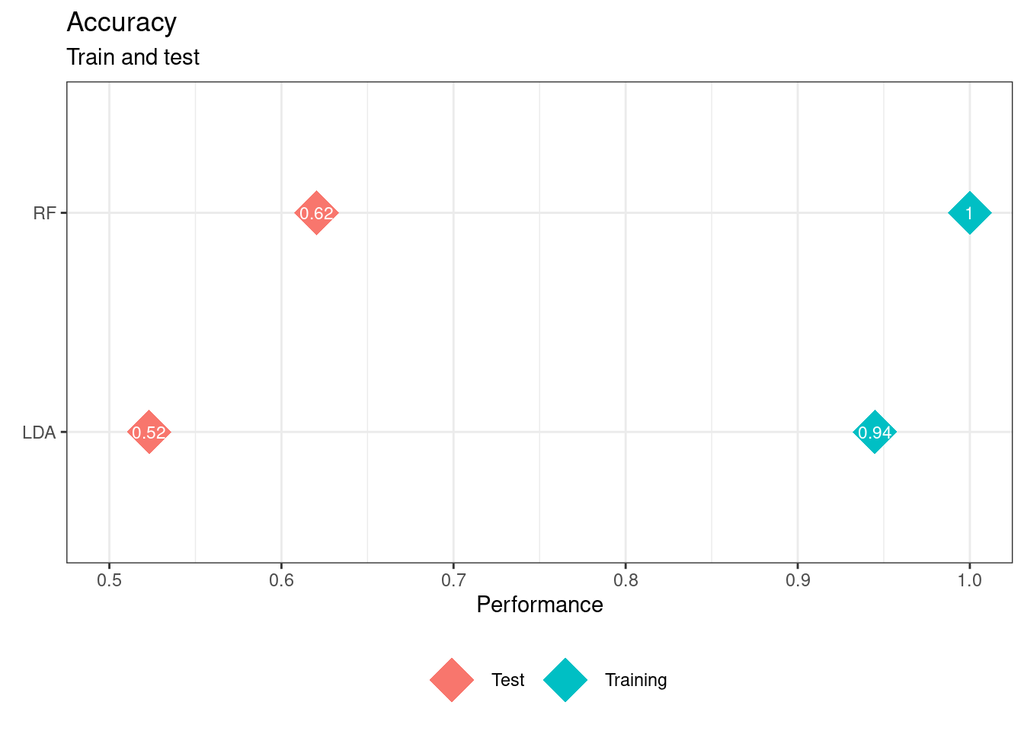

```r
ggplot(data = preds.scores,
       aes(x = reorder(object, accuracy), y = accuracy,
           color = dataType, label = round(accuracy, 2))) +
  geom_point(size = 10,shape=18) +
  geom_text(color = "white", size = 3) +
  scale_y_continuous(limits = c(0.5, 1)) +
  coord_flip() +
  labs(title = "Accuracy",
       subtitle = "Train and test",
       x = element_blank(),
       y = 'Performance') +
  theme_bw() +
  theme(legend.position = "bottom",
        legend.title = element_blank())
```

Our basal value is 0.5 as we have such percentage of cases in the majority class.

Finally, let’s check the importance of each of the genes in the best model:

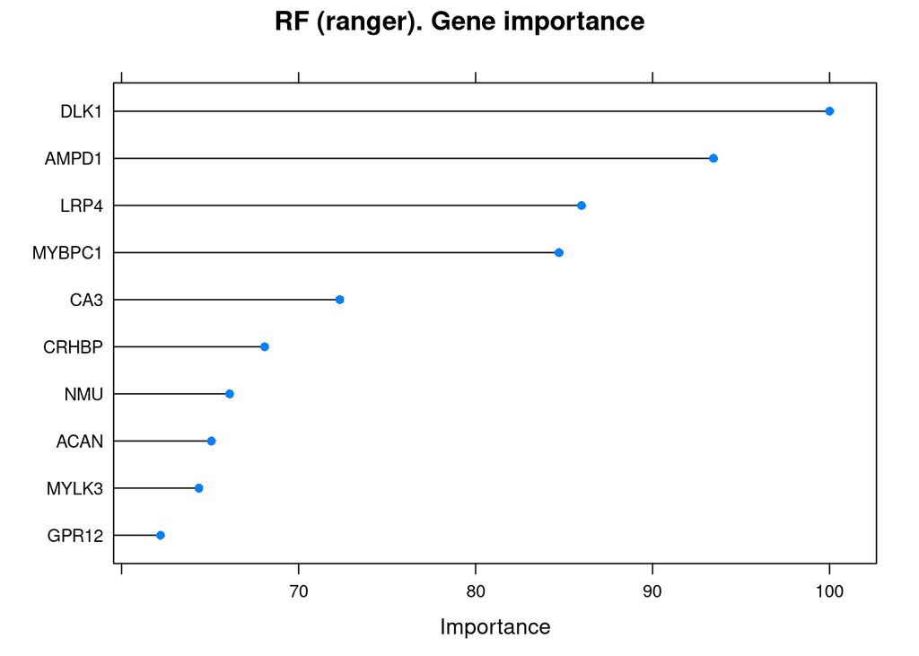

```r
importance.rf <- varImp(rf.model,scale = TRUE)
plot(importance.rf, main = 'RF (ranger). Gene importance',top=10)
```

We have omic and clinical data, we should use it carefully and think before starting a new analysis. Otherwise you’ll loose time to finish without relevant biological conclusions!

# Open questions

1. Are the important genes related with the biological condition?
2. Training errors close to 1 and test errors much lower means something?
3. According to the results could we improve the RF?
4. Why the OOB error is so similar to the CV error?
5. Are accuracy and kappa good performance measures for binary problems?
6. Can we extract conclusions from age at diagnosis binary divided into early and late?
7. Can we extract genetic conclusions from age at diagnosis?
8. Is a good idea to have imbalanced data?
9. What is missing to do a real cancer analysis using ML, R and Caret?
10. Moving from more 12,000 genes to more than 600 is a huge jump, isn’t?
11. Can you use feature selection or feature extraction techniques to reduce the dimensionality of the problem?
12. Can we learn something from the ML results in train and test? What does this kappa means? Is a better measure than accuracy?
13. Where do we have to go to check info from a gen?
14. Gens aren’t alone in the genome, they use to work together. Were do we have to go to check info from pathways?

# Summary

In this course we have covered the following concepts:

- Machine Learning for binary classification with Caret and R
- Exploratory data analysis
- We used Random Forest and LDA
- We learned how to automatically search for the best tune parameters for ML models using Caret
- Some models compute an importance for each of the features. This is not a p-value but it’s helpful
- We learned how sensible to data are ML algorithms. How important is to have a good dataset. How to clean data
- ggplot2, dplyr, reshape…

# References

- The Caret package. [link](https://topepo.github.io/caret/)
- An introduction to statistical learning: with applications in R. Gareth James, Daniela Witten, Trevor Hastie and Robert Tibshirani. [link](https://trevorhastie.github.io/ISLR/index.html)
- R and Caret by Joaquín Amat Rodrigo. [link](https://www.cienciadedatos.net/documentos/41_machine_learning_con_r_y_caret#Comparaci%C3%B3n_de_modelos). (CC BY 4.0)